# The Cat’s Guide to Data Wrangling: A Feline Approved Tutorial!

Anna Ng

2025-04-11

# Introduction

## What is Data Wrangling?

According to [Harvard’s Online Business School](https://online.hbs.edu/blog/post/data-wrangling), data wrangling refers to the variety of processes designed to transform raw data into more readily used formats.

This would include merging multiple data sources into a single dataset for analysis, identifying gaps in data and either filling or deleting them, deleting data that’s either unnecessary or irrelevant to the project you’re working on, and identifying extreme outliers in data and either explaining the discrepancies or removing them so that analysis can take place.

## Let’s Load the Necesarry Packages!

### tidyverse

For this tutorial, we would need [tidyverse](https://www.tidyverse.org/), an opinionated collection of R packages designed for data science. This package includes dplyr, ggplot2, stringr, readr, tibble, tidyr, forcats, lubridate and purrr. To install the complete package, use the function “install.packages()”. You only need to install the package **ONCE**.

Now, that the package is installed, load the package using the following code:

```r
#Make sure to load all necessary packages at the start of your code.
library(tidyverse)
```

We would also be using a pipe operator (|>) to chain multiple operations in a clearer way.

### dplyr

[dplyr](https://dplyr.tidyverse.org/) is a grammar of data manipulation, providing a consistent set of verbs that help you solve the most common data manipulation challenges.

The functions we would be using are:

- *mutate()*: adds new variables that are functions of existing variables
- *rename()*: changes the names of individual variables.
- *filter()*: picks cases based on their values.
- *summarise()*: reduces multiple values down to a single summary.
- *arrange()*: changes the ordering of the rows.
- *group_by()*: takes an existing table and converts it into a grouped table where operations are performed “by group.”

### ggplot2

[gplot2](https://ggplot2.tidyverse.org/articles/ggplot2.html) is used for producing visualizations of data.

The functions we would be using are:

- *ggplot()*: to create a new ggplot.
- *aes()*: to construct aesthetic mappings.
- *geom_bar()* & *geom_col()*: to produce bar charts.
- *labs()*: to modify plot labels.

**It is not necessary to individually load both dplyr and ggplot2 if you already loaded tidyverse.**

## Explore the Dataset!

Fo this tutorial, we would be working with the [Cats Dataset by Waqar Ali in Kaggle](https://www.kaggle.com/datasets/waqi786/cats-dataset/data). The dataset shows synthetically generated data from 1000 cats across various breeds, ages, weights, and colors. It does not show real-world pet registry data, however, it is still valuable for educational purposes—especially for pet enthusiasts and fellow cat lovers.

Install the dataset.

```r
cats_dataset <- read_csv("Data/cats_dataset.csv")
```

Check the dataset by running the following code:

```r
print(cats_dataset)
```

```
## # A tibble: 1,000 × 5
##    Breed            `Age (Years)` `Weight (kg)` Color         Gender
##    <chr>                    <dbl>         <dbl> <chr>         <chr>
##  1 Russian Blue                19             7 Tortoiseshell Female
##  2 Norwegian Forest            19             9 Tortoiseshell Female
##  3 Chartreux                    3             3 Brown         Female
##  4 Persian                     13             6 Sable         Female
##  5 Ragdoll                     10             8 Tabby         Male
##  6 Ocicat                       9             8 Blue          Female
##  7 Ragdoll                      6             5 Calico        Female
##  8 Abyssinian                  12             3 Tabby         Male
##  9 Oriental                     2             7 White         Male
## 10 Egyptian Mau                12             3 White         Male
## # ℹ 990 more rows
```

By using the function print() you can explore the dataset, including the first ten rows and some information in each column. Notice how the data type(double, character, etc.) can be seen below the column names in between < >, this is important as it shows the nature of the columns.

### Let’s look at the columns and what they mean!

- *Breed*: The simulated breed of the cat (e.g., Siamese, Persian, Bengal, etc.)
- *Age (Years)*: Modeled cat age, ranging from kittens to older adults
- *Weight (kg)*: Simulated weight in kilograms, reflecting natural feline variations
- *Color*: Generated coat colors and patterns (solid, tabby, calico, etc.)
- *Gender*: Modeled gender distribution (Male/Female)

However, the cats dataset does not give further information aside from the one provided at Kaggle, so a message would pop out mentioning this.

## Clean Dataset

After inspecting the dataset, you’ll notice how the column names are not very practical for coding and data analysis. Use the rename() function from the dplyr package to make them more readable and consistent. Use the filter(!is.na()) function to remove any possible missing data. Save this changes as ‘cats_cleaned’.

See the coding here:

```r
cats_cleaned <- cats_dataset |>
  rename(age_years = "Age (Years)",  #Notice how the format is the new name equal the current name of the column.
         weight_kg = "Weight (kg)",
         breed = "Breed",
         color = "Color",
         gender = "Gender") |>
  filter(!is.na(age_years),    #This is used to remove any missing data. Fortunately, there is no missing data!
         !is.na(weight_kg),
         !is.na(breed),
         !is.na(color),
         !is.na(gender))

cats_cleaned
```

```
## # A tibble: 1,000 × 5
##    breed            age_years weight_kg color         gender
##    <chr>                <dbl>     <dbl> <chr>         <chr>
##  1 Russian Blue            19         7 Tortoiseshell Female
##  2 Norwegian Forest        19         9 Tortoiseshell Female
##  3 Chartreux                3         3 Brown         Female
##  4 Persian                 13         6 Sable         Female
##  5 Ragdoll                 10         8 Tabby         Male
##  6 Ocicat                   9         8 Blue          Female
##  7 Ragdoll                  6         5 Calico        Female
##  8 Abyssinian              12         3 Tabby         Male
##  9 Oriental                 2         7 White         Male
## 10 Egyptian Mau            12         3 White         Male
## # ℹ 990 more rows
```

## Data Wrangling + Tutorials

### What is the gender distribution of cats within each breed? Which breed(s) have the highest proportion of male cats vs female cats?

To answer these questions, use the [count() function](https://www.rdocumentation.org/packages/dplyr/versions/1.0.10/topics/count), as it lets you quickly count the unique values of one or more variables. Make sure to check the amount of unique female and male cats in each breed.

Your result should look like this. See code below:

```r
cats_gender_breed <- cats_cleaned |>
  count(breed, gender)
cats_gender_breed
```

```
## # A tibble: 60 × 3
##    breed              gender     n
##    <chr>              <chr>  <int>
##  1 Abyssinian         Female    18
##  2 Abyssinian         Male      15
##  3 American Shorthair Female    17
##  4 American Shorthair Male      23
##  5 Balinese           Female    21
##  6 Balinese           Male      14
##  7 Bengal             Female    17
##  8 Bengal             Male      18
##  9 Birman             Female    19
## 10 Birman             Male      14
## # ℹ 50 more rows
```

#### Graph:

To make a visual representation of the number of female and male cats per breed, let’s make a bar chart! Plot the count of cats in the x-axis and the breed in the y-axis. Fill the bars by the gender of the cat. The function ‘position = fill’ would make a stacked bar to better represent the proportions and not raw data. The function ‘stat = “identity”’ needs to be added as we are using pre-counted values.

Make sure to give your plot all the necessary labels, such as the title and axis labels.

Your graph should look like this. Check the code + explanations below:

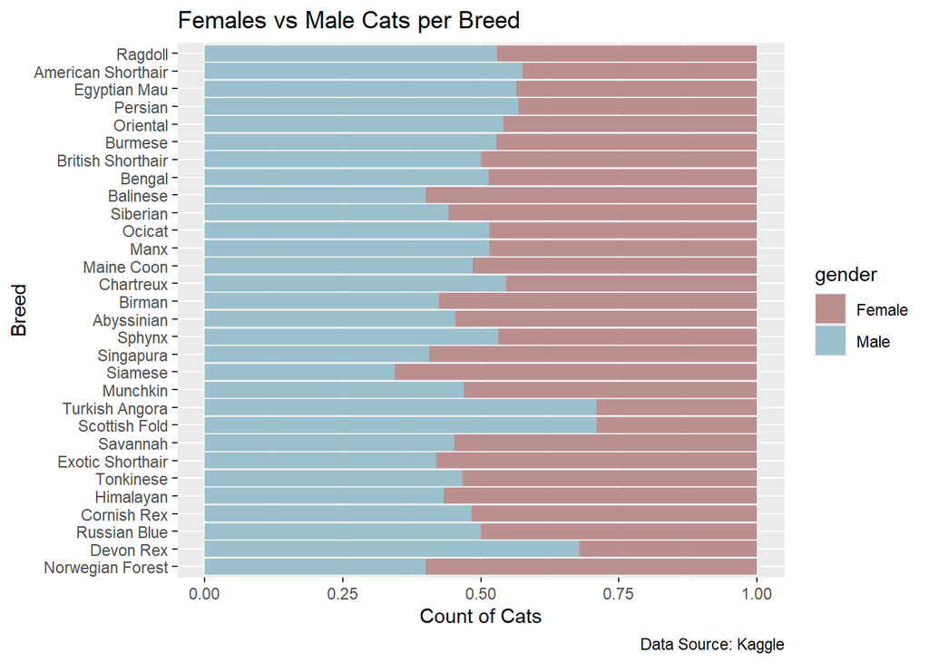

```r
ggplot(cats_gender_breed, aes(x = n, y = reorder(breed, n), fill = gender)) + #reorder function would reorder breeds by count
  geom_bar(stat = "identity", position = "fill") +
  labs(
    title = "Females vs Male Cats per Breed",
    x = "Count of Cats",
    y ="Breed",
    caption = "Data Source: Kaggle"
  ) +
  scale_fill_manual(values = c("rosybrown", "lightblue3")) #Use this function to manually change the colors of the graph if wanted.
```

```r
#Answer to the questions: Turkish Angoras and Scottish Folds have the highest proportion of male cats vs female cats.
```

### Which breed has the highest average weight? Only show the Top 10 Heaviest Cats.

Use the function group_by() to group the all the cats by their respective breeds. Now, use summarise() to combine all the weights, make sure to add mean() as the average value is wanted. Use arrange() to order the rows in a specific way. desc() would correspond to a descending order, meaning from heaviest to lightest cat. head() would allow you to only show the first n rows present in your dataset.

Your results should look like this. See coding below:

```r
cats_avg_weight <- cats_cleaned |>
  filter(!is.na(breed), !is.na(weight_kg)) |> #Filter for any missing data, not a necessary step if you already cleaned you data.
  group_by(breed) |>
  summarise(avg_weight = mean(weight_kg, na.rm = TRUE)) |> #na.rm = TRUE is another simple way of removing misisng data.
  arrange(desc(avg_weight)) |>
  head(10) #This would only show the ten first rows as we only want the top 10.

cats_avg_weight
```

```
## # A tibble: 10 × 2
##    breed              avg_weight
##    <chr>                   <dbl>
##  1 Himalayan                6.6
##  2 Munchkin                 6.16
##  3 Ocicat                   6.09
##  4 American Shorthair       5.98
##  5 Manx                     5.82
##  6 Egyptian Mau             5.79
##  7 Siamese                  5.75
##  8 Birman                   5.70
##  9 Singapura                5.69
## 10 Savannah                 5.65
```

```r
#Answer: The Himalayan cat is the heaviest one in the dataset.
```

#### Graph:

Let’s do another bar chart! Plot the breed in the x-axis and avg_weight in the y-axis.

Your graph should look like this. See coding below:

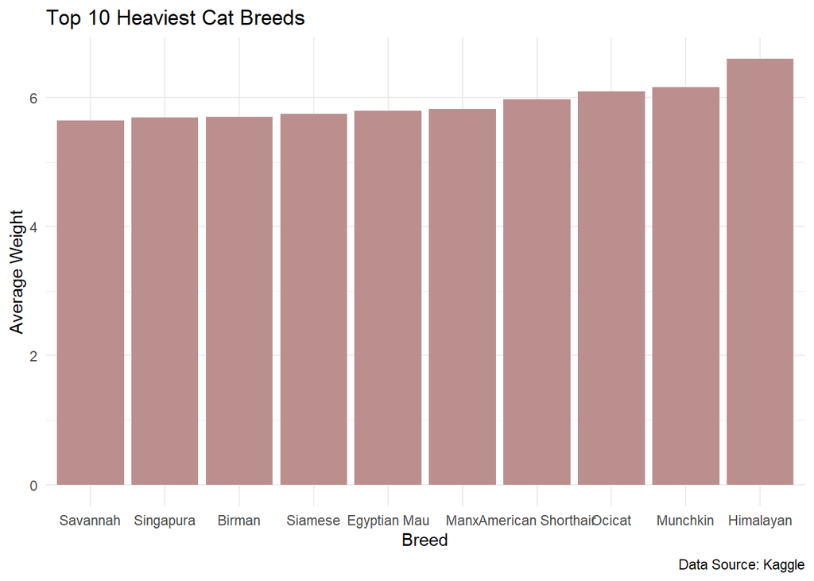

```r
  ggplot(cats_avg_weight, aes(x = reorder(breed, avg_weight), y = avg_weight)) + #reorider function would reorder the breeds by the average weight of the cat.
  geom_col(fill = "rosybrown") + #Use fill to add the color of your choice.
  labs(title = "Top 10 Heaviest Cat Breeds",
       x = "Breed",
       y = "Average Weight",
       caption = "Data Source: Kaggle") +
  theme_minimal()
```

## Now is your turn!

### What is the most common cat breed in the dataset? What is the fraction of the most common cat breed?

Use all the past exercises to answer these questions!

*Hint*: To calculate the fraction of the most common cat breed, use mutate to create a new column that divides the number of the most common breed by all the total number of cats.

#### Graph:

Now you have to plot your results!

Your graoh should look like this.

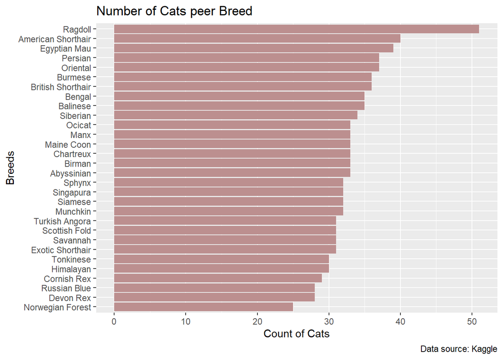

```r
ggplot(top_cat_breed, aes(x = n, y = reorder(breed, n))) +
  geom_bar(stat = "identity", fill = "rosybrown") +
  labs(
    title = "Number of Cats peer Breed",
    x = "Count of Cats",
    y ="Breeds",
    caption = "Data source: Kaggle"
  )
```

## Conclusions

From this dataset, we get to learn fun facts from diverse cats in the dataset, such as the heaviest cat breed and the most common cat breed. Despite not being shown in this tutorial, more questions could be ask regarding the cat’s age and even coloring. Overall, data wrangling is so useful for ensuring readable data in a format that is suitable for coding and further work. Data wrangling is so powerful as it improves data quality and saves time for future data manipulation. This tutorial would not have been as smoother without the use of diverse functions to clean the dataset.